# Introduction to R

Yingyi Zhu

06/01/2021

# 1 Introduction

Learning Objectives

- Describe R and RStudio.
- Interact with R using RStudio.
- Use the various features of RStudio.
- Learn basic R operation.
- Generate the same RMarkdown report in HTML format.

## 1.1 What is R?

The common misconception is that R is a programming language but in fact it is much more than that. Let’s think of R as an environment for statistical computing and graphics, which brings together a number of features to provide powerful functionality.

The R environment combines:

- effective handling of big data
- collection of integrated tools
- graphical facilities
- simple and effective programming language

## 1.2 Why use R?

[figure not shown]

R is a powerful, extensible environment. It has a wide range of statistics and general data analysis and visualization capabilities.

- Data handling, wrangling, and storage
- Wide array of statistical methods and graphical techniques available
- Easy to install on any platform and use (and it’s free!)
- Open source with a large and growing community of peers

## 1.3 What is RStudio?

RStudio is freely available open-source Integrated Development Environment (IDE). RStudio provides an environment with many features to make using R easier and is a great alternative to working on R in the terminal.

- Graphical user interface, not just a command prompt
- Great learning tool
- Free for academic use
- Platform agnostic
- Open source

## 1.4 RStudio Interface

The RStudio interface has four main panels:

- Console: where you can type commands and see output. The console is all you would see if you ran R in the command line without RStudio.
- Script editor: where you can type out commands and save to file. You can also submit the commands to run in the console.
- Environment/History: environment shows all active objects and history keeps track of all commands run in console
- Files/Plots/Packages/Help

# 2 Assignment operator

Variables are assigned usually using the <- operator. The = operator also works in a similar way for most part.

```r
x <- 4
x = 4
x
```

```
## [1] 4
```

# 3 Arithmetic operators

The commonly used arithmetic operators are shown below returning a number.

```r
x <- 4
y <- 2

# add
x + y
```

```
## [1] 6
```

```r
# subtract
x - y
```

```
## [1] 2
```

```r
# multiply
x * y
```

```
## [1] 8
```

```r
# divide
x / y
```

```
## [1] 2
```

```r
# modulus
x %% y
```

```
## [1] 0
```

```r
# power
x ^ y
```

```
## [1] 16
```

# 4 Logical operators

Logical operators return a logical TRUE or FALSE.

```r
# equal to?
x == y
```

```
## [1] FALSE
```

```r
# not equal to?
x != y
```

```
## [1] TRUE
```

```r
# greater than?
x > y
```

```
## [1] TRUE
```

```r
# less than?
x < y
```

```
## [1] FALSE
```

```r
# greater than or equal to?
x >= y
```

```
## [1] TRUE
```

```r
# less than or equal to?
x <= y
```

```
## [1] FALSE
```

# 5 Data types

```r
class(1)
```

```
## [1] "numeric"
```

```r
class("hello")
```

```
## [1] "character"
```

```r
class(T)
```

```
## [1] "logical"
```

```r
x <- c(2,3,4,5,6)
y <- c("a","c","d","e")
z <- factor(c("a","c","d","e"))
class(z)
```

```
## [1] "factor"
```

```r
x <- matrix(c(2,3,4,5,6,7),nrow=3,ncol=2)
class(x)
```

```
## [1] "matrix" "array"
```

```r
str(x)
```

```
##  num [1:3, 1:2] 2 3 4 5 6 7
```

```r
dfr <- data.frame(x = 1:3, y = c("a", "b", "c"))
print(dfr)
```

```
##   x y
## 1 1 a
## 2 2 b
## 3 3 c
```

```r
class(dfr)
```

```
## [1] "data.frame"
```

```r
str(dfr)
```

```
## 'data.frame':    3 obs. of  2 variables:
##  $ x: int  1 2 3
##  $ y: chr  "a" "b" "c"
```

# 6 Accessors

Vectors positions can be accessed using []. R follows 1-based indexing.

```r
x <- c(2,3,4,5,6)
x
```

```
## [1] 2 3 4 5 6
```

```r
x[2]
```

```
## [1] 3
```

Dataframe or matrix positions can be accessed using [] specifying row and column like [row,column].

```r
dfr <- data.frame(x = 1:3, y = c("a", "b", "c"))
dfr
```

```
##   x y
## 1 1 a
## 2 2 b
## 3 3 c
```

```r
dfr[1,]
```

```
##   x y
## 1 1 a
```

```r
dfr[,1]
```

```
## [1] 1 2 3
```

```r
dfr[2,2]
```

```
## [1] "b"
```

# 7 Functions

```r
# generate 10 random numbers between 1 and 200
x <- sample(x=1:200,10)
x
```

```
##  [1]  68  58 120  23 139  27  47 162  49 197
```

```r
# length
length(x)
```

```
## [1] 10
```

```r
# sum
sum(x)
```

```
## [1] 890
```

```r
# mean
mean(x)
```

```
## [1] 89
```

```r
# median
median(x)
```

```
## [1] 63
```

```r
# min
min(x)
```

```
## [1] 23
```

```r
# log
log(x)
```

```
##  [1] 4.219508 4.060443 4.787492 3.135494 4.934474 3.295837 3.850148 5.087596
##  [9] 3.891820 5.283204
```

```r
# exponent
exp(x)
```

```
##  [1] 3.404276e+29 1.545539e+25 1.304181e+52 9.744803e+09 2.327732e+60
##  [6] 5.320482e+11 2.581313e+20 2.268329e+70 1.907347e+21 3.597601e+85
```

```r
# square-root
sqrt(x)
```

```
##  [1]  8.246211  7.615773 10.954451  4.795832 11.789826  5.196152  6.855655
##  [8] 12.727922  7.000000 14.035669
```

```r
# round
round(x)
```

```
##  [1]  68  58 120  23 139  27  47 162  49 197
```

```r
# sort
sort(x)
```

```
##  [1]  23  27  47  49  58  68 120 139 162 197
```

Some useful string functions.

```r
a <- "sunny"
b <- "day"

# join
paste(a, b)
```

```
## [1] "sunny day"
```

```r
# find a pattern
grep("sun", a)
```

```
## [1] 1
```

```r
# number of characters
nchar("sunny")
```

```
## [1] 5
```

```r
# to uppercase
toupper("sunny")
```

```
## [1] "SUNNY"
```

```r
# to lowercase
tolower("SUNNY")
```

```
## [1] "sunny"
```

```r
# replace pattern
sub("sun", "fun", "sunny")
```

```
## [1] "funny"
```

```r
# substring
substr("sunny", start=1, stop=3)
```

```
## [1] "sun"
```

Some general functions

```r
print("hello")
```

```
## [1] "hello"
```

```r
print("world")
```

```
## [1] "world"
```

```r
cat("hello")
```

```
## hello
```

```r
cat(" world")
```

```
##  world
```

```r
cat("\nhello\nworld")
```

```
##
## hello
## world
```

# 8 Merging

Two strings can be joined together using paste().

```r
a <- "sunny"
b <- "day"

paste(a, b)
```

```
## [1] "sunny day"
```

```r
paste(a, b, sep="-")
```

```
## [1] "sunny-day"
```

The function c() is used to concatenate objects.

```r
a <- "sunny"
b <- "day"

c(a,b)
```

```
## [1] "sunny" "day"
```

The function cbind() is used to join two dataframes column-wise.

```r
dfr1 <- data.frame(x = 1:3, y = c("a", "b", "c"))
dfr2 <- data.frame(p = 4:6, q = c("d", "e", "f"))
dfr1
```

```
##   x y
## 1 1 a
## 2 2 b
## 3 3 c
```

```r
dfr2
```

```
##   p q
## 1 4 d
## 2 5 e
## 3 6 f
```

```r
cbind(dfr1,dfr2)
```

```
##   x y p q
## 1 1 a 4 d
## 2 2 b 5 e
## 3 3 c 6 f
```

Similarily, rbind() is used to join two dataframes row-wise.

```r
dfr1 <- data.frame(x = 1:3, y = c("a", "b", "c"))
dfr2 <- data.frame(x = 4:6, y = c("d", "e", "f"))
dfr1
```

```
##   x y
## 1 1 a
## 2 2 b
## 3 3 c
```

```r
dfr2
```

```
##   x y
## 1 4 d
## 2 5 e
## 3 6 f
```

```r
rbind(dfr1,dfr2)
```

```
##   x y
## 1 1 a
## 2 2 b
## 3 3 c
## 4 4 d
## 5 5 e
## 6 6 f
```

Two dataframes can be merged based on a shared column using the merge() function.

```r
dfr1 <- data.frame(x = 1:4, p = c("a", "b", "c","d"))
dfr2 <- data.frame(x = 3:6, q = c("l", "m", "n","o"))
dfr1
```

```
##   x p
## 1 1 a
## 2 2 b
## 3 3 c
## 4 4 d
```

```r
dfr2
```

```
##   x q
## 1 3 l
## 2 4 m
## 3 5 n
## 4 6 o
```

```r
merge(dfr1,dfr2,by="x")
```

```
##   x p q
## 1 3 c l
## 2 4 d m
```

```r
merge(dfr1,dfr2,by="x",all.x=T)
```

```
##   x p    q
## 1 1 a <NA>
## 2 2 b <NA>
## 3 3 c    l
## 4 4 d    m
```

```r
merge(dfr1,dfr2,by="x",all.y=T)
```

```
##   x    p q
## 1 3    c l
## 2 4    d m
## 3 5 <NA> n
## 4 6 <NA> o
```

```r
merge(dfr1,dfr2,by="x",all=T)
```

```
##   x    p    q
## 1 1    a <NA>
## 2 2    b <NA>
## 3 3    c    l
## 4 4    d    m
## 5 5 <NA>    n
## 6 6 <NA>    o
```

# 9 Read and write files

ead comma separated file (csv) using read.csv function:

> table1 <- read.csv(“example_table.csv”)

Set the first column as the row names:

> table1 <- read.csv(“example_table.csv”, row.names = 1)

Or use the more general read.table function and specify the separater:

> table1 <- read.table(“example_table.csv”, sep = “,”)

We will need to set the row names and column names manually:

> table1 <- read.table(“example_table.csv”, sep = “,”, row.names = 1, header = T)

Write the variable to csv format using write.csv function:

> write.csv(table1, “example_table1.csv”)

# 10 Packages

## 10.1 CRAN

The Comprehensive R Archive Network CRAN is the biggest archive of R packages. There are few requirements for uploading packages besides building and installing succesfully, hence documentation and support is often minimal and figuring how to use these packages can be a challenge it itself. CRAN is the default repository R will search to find packages to install:

> install.packages(“YOUR_PACKAGE_NAME”)

```r
install.packages("devtools")

# or multiple packages

install.packages(c("ggplot2", "stringr"))
```

## 10.2 BioConductor

Bioconductor is a repository of R-packages specifically for biological analyses. It has the strictest requirements for submission, including installation on every platform and full documentation with a tutorial (called a vignette) explaining how the package should be used. Bioconductor also encourages utilization of standard data structures/classes and coding style/naming conventions, so that, in theory, packages and analyses can be combined into large pipelines or workflows.

Bioconductor also requires creators to support their packages and has a regular 6-month release schedule. Make sure you are using the most recent release of bioconductor before trying to install packages for the course.

```r
if (!requireNamespace("BiocManager", quietly = TRUE))
    install.packages("BiocManager")

BiocManager::install("PACKAGE_NAME", ask = FALSE)
```

## 10.3 GitHub

GitHub isn’t specific to R, any code of any type in any state can be uploaded. There is no guarantee a package uploaded to github will even install, nevermind do what it claims to do. R packages can be downloaded and installed directly from github using the “devtools” package installed above.

```r
devtools::install_github("username/repository")
```

# 11 Graphics

## 11.1 Base

R is an excellent tool for creating graphs and plots. The graphic capabilities and functions provided by the base R installation is called the base R graphics. Numerous packages exist to extend the functionality of base graphics.

We can try out plotting a few of the common plot types. Let’s start with a scatterplot. First we create a data.frame as this is the most commonly used data object.

```r
dfr <- data.frame(a=sample(1:100,10),b=sample(1:100,10))
```

Now we have a dataframe with two continuous variables that can be plotted against each other.

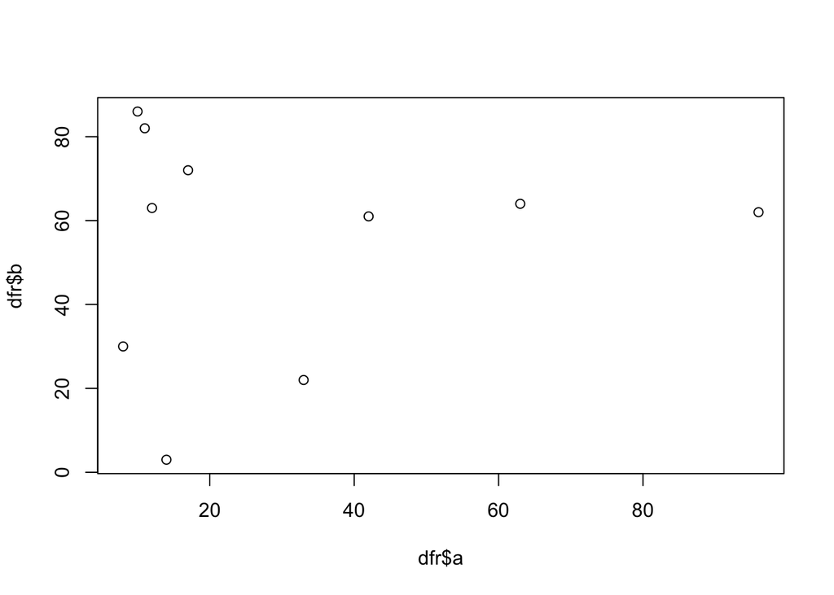

```r
plot(dfr$a,dfr$b)
```

This is probably the simplest and most basic plots. We can modify the x and y axis labels.

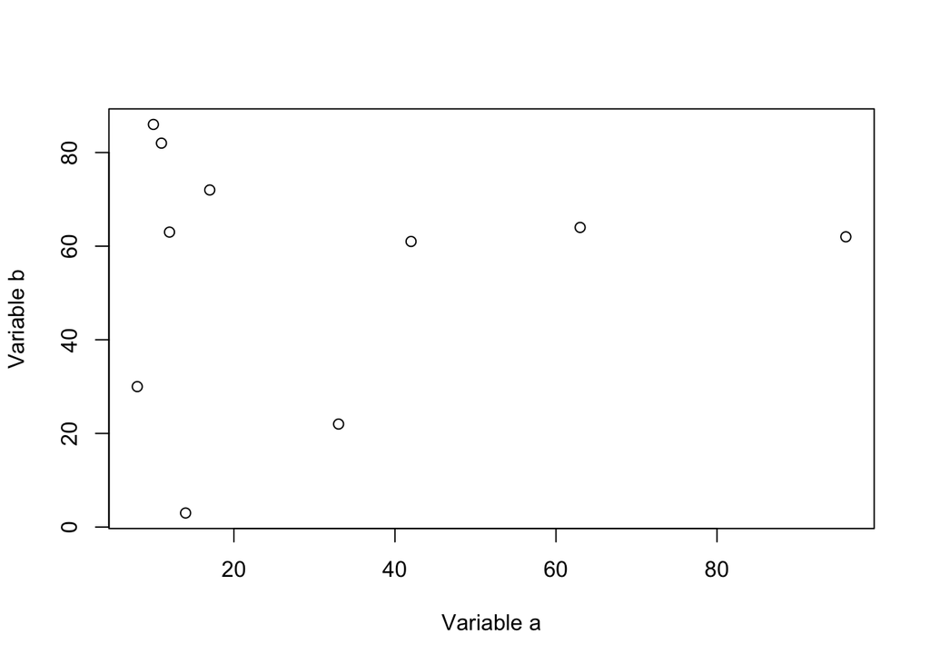

```r
plot(dfr$a,dfr$b,xlab="Variable a",ylab="Variable b")
```

We can change the point to a line.

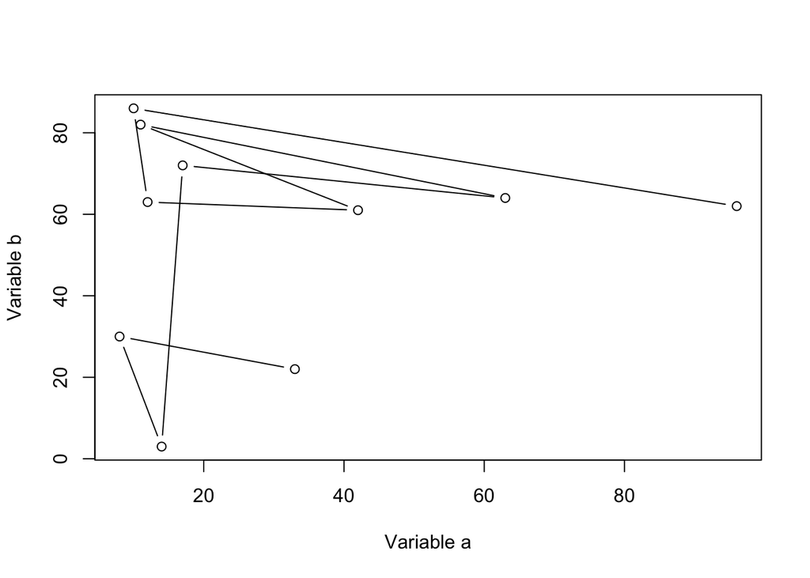

```r
plot(dfr$a,dfr$b,xlab="Variable a",ylab="Variable b",type="b")
```

Let’s add a categorical column to our dataframe.

```r
dfr$cat <- rep(c("C1","C2"),each=5)
```

And then colour the points by category.

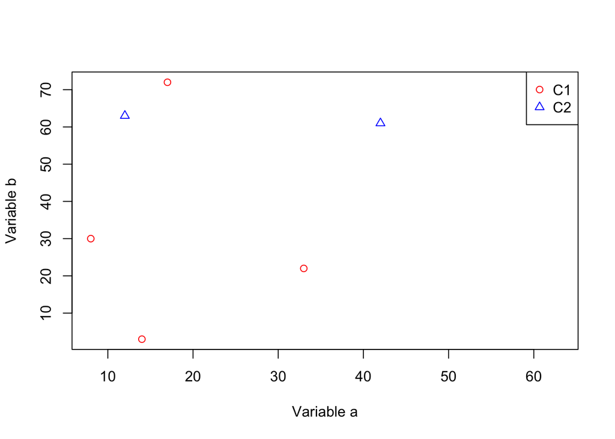

```r
# subset data
dfr_c1 <- subset(dfr,dfr$cat == "C1")
dfr_c2 <- subset(dfr,dfr$cat == "C2")

plot(dfr_c1$a,dfr_c1$b,xlab="Variable a",ylab="Variable b",col="red",pch=1)
points(dfr_c2$a,dfr_c2$b,col="blue",pch=2)

legend(x="topright",legend=c("C1","C2"),
       col=c("red","blue"),pch=c(1,2))
```

Let’s create a barplot.

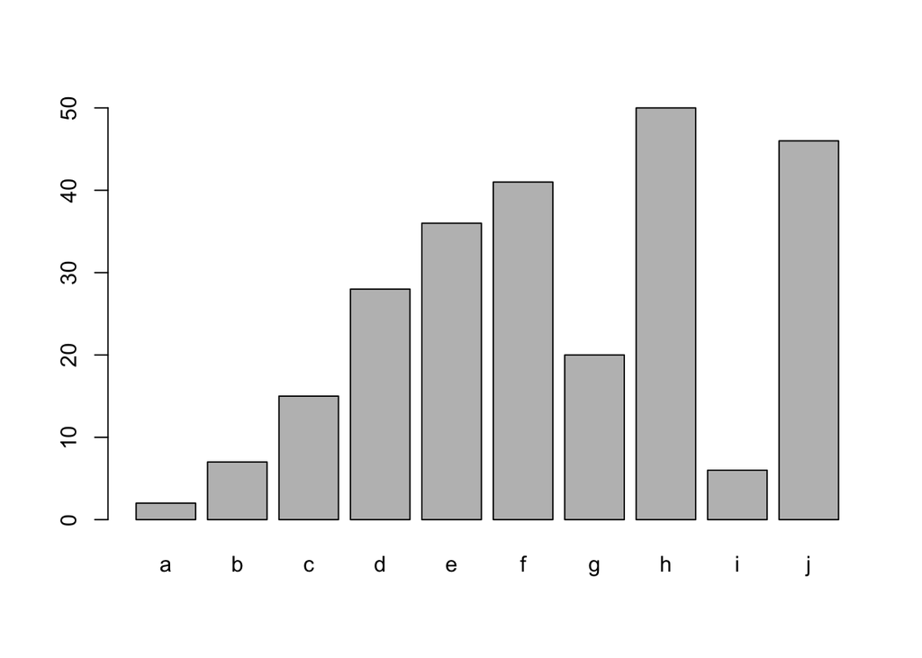

```r
ldr <- data.frame(a=letters[1:10],b=sample(1:50,10))
barplot(ldr$b,names.arg=ldr$a)
```

## 11.2 Grid

Grid graphics have a completely different underlying framework compared to base graphics. Generally, base graphics and grid graphics cannot be plotted together. The most popular grid-graphics based plotting library is ggplot2.

Let’s create the same plot are before using ggplot2. Make sure you have the package installed.

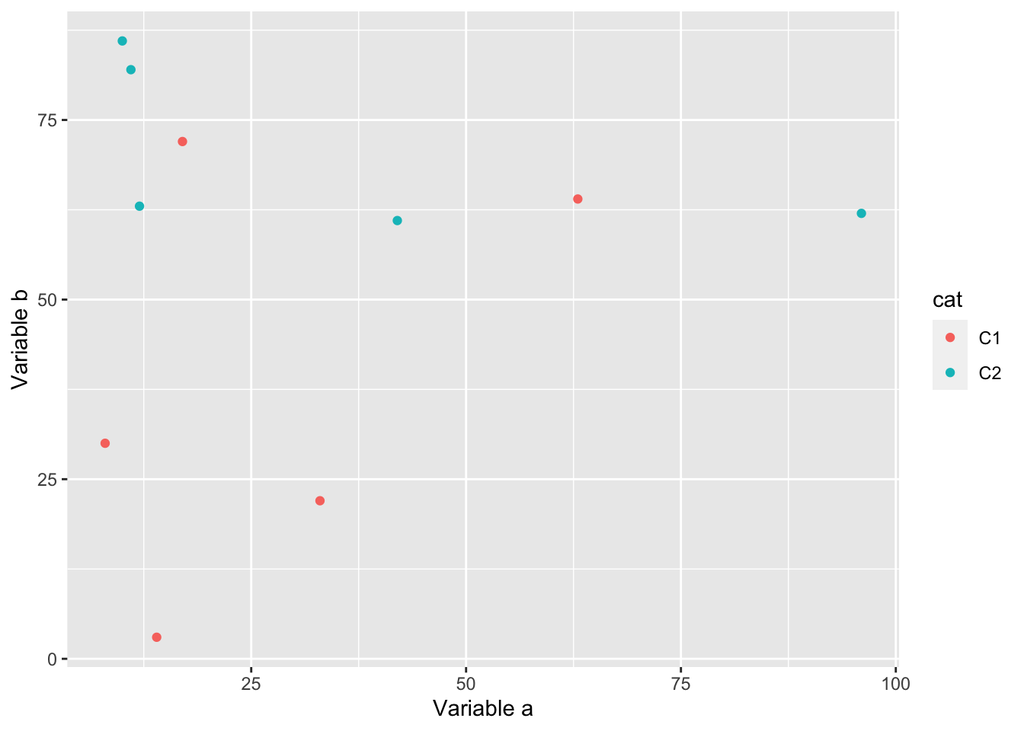

```r
library(ggplot2)

ggplot(dfr,aes(x=a,y=b,colour=cat))+
  geom_point()+
  labs(x="Variable a",y="Variable b")
```

It is generally easier and more consistent to create plots using the ggplot2 package compared to the base graphics.

Let’s create a barplot as well.

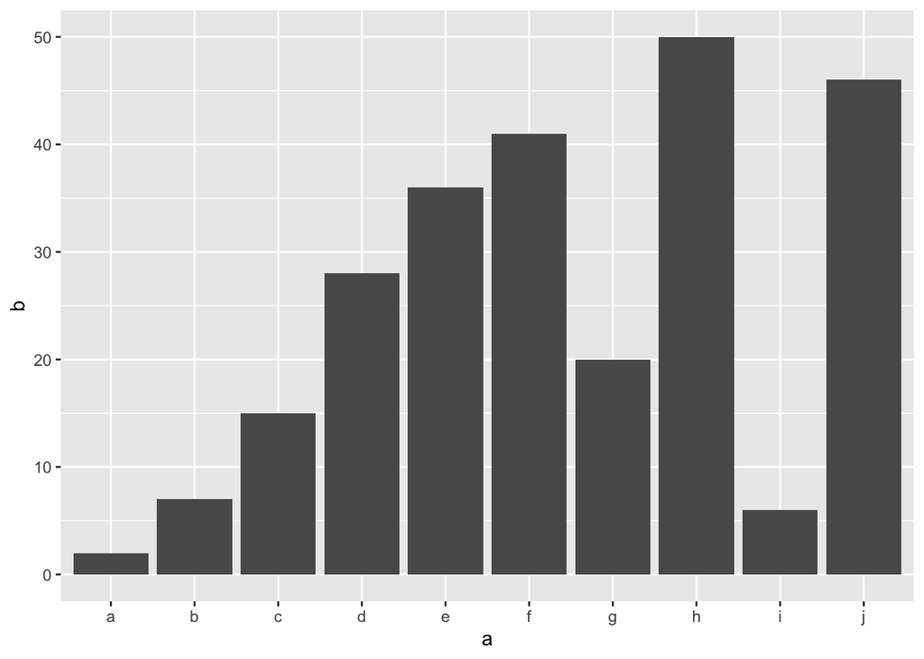

```r
ggplot(ldr,aes(x=a,y=b))+
  geom_bar(stat="identity")
```

# 12 Input/Output

Input and output of data and images is an important aspect with data analysis.

## 12.1 Text

Data can come in a variety of formats which needs to be read into R and converted to an R data type.

```r
#dfr <- read.table("iris.txt",header=TRUE,stringsAsFactors=F)
```

It’s always a good idea to check the data after import.

```r
head(dfr)
```

```
##    a  b cat
## 1 33 22  C1
## 2  8 30  C1
## 3 14  3  C1
## 4 17 72  C1
## 5 63 64  C1
## 6 11 82  C2
```

```r
str(dfr)
```

```
## 'data.frame':    10 obs. of  3 variables:
##  $ a  : int  33 8 14 17 63 11 42 12 10 96
##  $ b  : int  22 30 3 72 64 82 61 63 86 62
##  $ cat: chr  "C1" "C1" "C1" "C1" ...
```

Check ?read.table for other wrapper functions to read in text files.

Let’s filter this data.frame and create a new dataset.

```r
dfr1 <- dfr[dfr$Species == "setosa",]
```

And we can write this as a text file.

```r
write.table(dfr1,"iris-setosa.txt",sep="\t",row.names=F,quote=F)
```

## 12.2 Base graphics

The general idea for saving plots is open a graphics device, create the plot and then close the device. We will use png here. Check out ?png for the arguments and other devices.

```r
dfr <- data.frame(a=sample(1:100,10),b=sample(1:100,10))

png(filename="plot-base.png")
plot(dfr$a,dfr$b)
dev.off()
```

## 12.3 ggplot2

The same idea can be applied to ggplot2, but in a slightly different way. First save the file to a variable, and then export the plot.

```r
p <- ggplot(dfr,aes(a,b)) + geom_point()

png(filename="plot-ggplot-1.png")
print(p)
dev.off()
```

ggplot2 also has another easier helper function to export images.

```r
ggsave(filename="plot-ggplot-2.png",plot=p)
```

# 13 Build a report in HTML format

RStudio includes a “Knit” button that enables you to render an .Rmd and preview it using a single click or keyboard shortcut

Click File -> Knit document

# 14 Session Infomation

To improve reproducibility, we usually print out the session information, which contains all loaded packages and versions.

[session information not shown]

# 15 Reference

[Intro to R](https://nbisweden.github.io/workshop-RNAseq/2011/lab_r.html#9_Graphics)

[Training-modules-IntroR](https://github.com/hbctraining/Training-modules/tree/master/IntroR)